# Lab 8: Cannabis Types

Author

Diya Patel

GitHub link: https://github.com/diyapatel040124/GSB-544-Computing-and-Machine-Learning/blob/main/Lab_8.html

```python
import pandas as pd
import numpy as np
from sklearn.pipeline import Pipeline
from sklearn.neighbors import KNeighborsClassifier
from sklearn.tree import DecisionTreeClassifier
from sklearn.linear_model import LogisticRegression
from sklearn.preprocessing import StandardScaler, OneHotEncoder
from sklearn.discriminant_analysis import LinearDiscriminantAnalysis as LDA
from sklearn.metrics import classification_report, confusion_matrix
from sklearn.model_selection import train_test_split, StratifiedKFold, GridSearchCV, cross_val_score
from sklearn.compose import ColumnTransformer
```

```python
df = pd.read_csv('cannabis_full.csv')
df = df.dropna()
df.head()
```

|  | Strain | Type | Rating | Effects | Flavor | Creative | Energetic | Tingly | Euphoric | Relaxed | ... | Ammonia | Minty | Tree | Fruit | Butter | Pineapple | Tar | Rose | Plum | Pear |
| --- | --- | --- | --- | --- | --- | --- | --- | --- | --- | --- | --- | --- | --- | --- | --- | --- | --- | --- | --- | --- | --- |
| 0 | 100-Og | hybrid | 4.0 | Creative,Energetic,Tingly,Euphoric,Relaxed | Earthy,Sweet,Citrus | 1.0 | 1.0 | 1.0 | 1.0 | 1.0 | ... | 0.0 | 0.0 | 0.0 | 0.0 | 0.0 | 0.0 | 0.0 | 0.0 | 0.0 | 0.0 |
| 1 | 98-White-Widow | hybrid | 4.7 | Relaxed,Aroused,Creative,Happy,Energetic | Flowery,Violet,Diesel | 1.0 | 1.0 | 0.0 | 0.0 | 1.0 | ... | 0.0 | 0.0 | 0.0 | 0.0 | 0.0 | 0.0 | 0.0 | 0.0 | 0.0 | 0.0 |
| 2 | 1024 | sativa | 4.4 | Uplifted,Happy,Relaxed,Energetic,Creative | Spicy/Herbal,Sage,Woody | 1.0 | 1.0 | 0.0 | 0.0 | 1.0 | ... | 0.0 | 0.0 | 0.0 | 0.0 | 0.0 | 0.0 | 0.0 | 0.0 | 0.0 | 0.0 |
| 3 | 13-Dawgs | hybrid | 4.2 | Tingly,Creative,Hungry,Relaxed,Uplifted | Apricot,Citrus,Grapefruit | 1.0 | 0.0 | 1.0 | 0.0 | 1.0 | ... | 0.0 | 0.0 | 0.0 | 0.0 | 0.0 | 0.0 | 0.0 | 0.0 | 0.0 | 0.0 |
| 4 | 24K-Gold | hybrid | 4.6 | Happy,Relaxed,Euphoric,Uplifted,Talkative | Citrus,Earthy,Orange | 0.0 | 0.0 | 0.0 | 1.0 | 1.0 | ... | 0.0 | 0.0 | 0.0 | 0.0 | 0.0 | 0.0 | 0.0 | 0.0 | 0.0 | 0.0 |

5 rows × 69 columns

Part One: Binary Classification Create a dataset that is limited to only the Sativa and Indica type cannabis strains. Create a final best model for each of the four new model types: LDA, QDA, SVC, and SVM. For each, you should: - Choose a metric you will use to select your model, and briefly justify your choice. - Find the best model for predicting the Type variable. Don’t forget to tune any hyperparameters. - Report the cross-validated metric. - Fit the final model. - Output a confusion matrix

Q1: LDA

```python
df_types = df[df["Type"].isin(["sativa", "indica"])]
df_types

# define the feature set and target variable
X = df_types.drop("Type", axis = 1)
y = df_types["Type"]

# create training splits
X_train, X_test, y_train, y_test = train_test_split(
    X, y, test_size = 0.2, random_state = 42, stratify = y
)

num_cols = X.select_dtypes(include=[np.number]).columns
cat_cols = X.select_dtypes(exclude=[np.number]).columns

ct = ColumnTransformer(
    transformers = [
        ("num", StandardScaler(), num_cols),
        ("cat", OneHotEncoder(handle_unknown="ignore", sparse_output=False), cat_cols)
    ]
)
```

```python
lda_pipe = Pipeline([
    ("ct", ct),
    ("lda", LDA())
])

param_grid = [
    {"lda__solver": ["lsqr", "eigen"], "lda__shrinkage": ["auto", 0.1, 0.3, 0.5, 0.7, 0.9]},
]

cv = StratifiedKFold(n_splits=5, shuffle=True, random_state=42)

lda_grid = GridSearchCV(
    lda_pipe,
    param_grid=param_grid,
    scoring={"f1_macro": "f1_macro", "accuracy": "accuracy"},
    refit = "f1_macro",
    cv=cv,
    n_jobs=-1
)

lda_grid.fit(X, y)

print("Best params:", lda_grid.best_params_)
print("CV best macro-F1: {:.3f}".format(lda_grid.best_score_))

y_pred = lda_grid.predict(X_test)
print("\nClassification Report:\n", classification_report(y_test, y_pred, digits=3))

cm = confusion_matrix(y_test, y_pred, labels=["indica", "sativa"])
print("\nConfusion Matrix:\n", cm)
```

```
Best params: {'lda__shrinkage': 'auto', 'lda__solver': 'lsqr'}
CV best macro-F1: 0.857

Classification Report:
               precision    recall  f1-score   support

      indica      0.939     0.932     0.935       132
      sativa      0.892     0.902     0.897        82

    accuracy                          0.921       214
   macro avg      0.915     0.917     0.916       214
weighted avg      0.921     0.921     0.921       214


Confusion Matrix:
 [[123   9]
 [  8  74]]
```

Best params: {’lda__shrinkage’: ‘auto’, ’lda__solver’: ‘lsqr’} Because the dataset was one-hot-encoded into columns, the best solver was lsqr which supported the shrinkage, and shrinkage helps stabilize LDA when feature correlations are too high.

CV best macro-F1: 0.857

Classification Report: precision recall f1-score support

```
  indica      0.939     0.932     0.935       132
  sativa      0.892     0.902     0.897        82

accuracy                          0.921       214
```

macro avg 0.915 0.917 0.916 214 weighted avg 0.921 0.921 0.921 214

With a score of 0.916, the f1-score indicated the model performed well and was stable

Confusion Matrix: [[123 9] –> out of 132 Indica strains, 123 are classified as Indica [ 8 74]] –> out of 82 Sativa strains, 74 are classified as Sativa and 8 were misclassified

Metric Selection: F1-Score For LDA, I used the macro F1-Score to find the average of the F1-scores across both of the binary classes which will weigh them equally. F1 makes sure that precision and recall are both balanced which can come up when misclassifying either Sativa or Indica strains. F1 also treats both binary classes equally even when the class sizes are not equal. Macro F1 is the most equal and fair metric for comparing the hyperparameter values.

Q2: QDA

```python
from sklearn.discriminant_analysis import QuadraticDiscriminantAnalysis as QDA

qda_pipe = Pipeline([
    ("ct", ct),
    ("qda", QDA())
])

param_grid = {
    "qda__reg_param": [0.01, 0.05, 0.1, 0.2, 0.5]
}

X_train, X_test, y_train, y_test = train_test_split(
    X, y, test_size=0.2, random_state=42, stratify=y
)

cv = StratifiedKFold(n_splits=5, shuffle=True, random_state=42)

qda_grid = GridSearchCV(
    qda_pipe,
    param_grid=param_grid,
    scoring="f1_macro",
    cv=cv,
    n_jobs=-1
)

qda_grid.fit(X_train, y_train)

print("Best params:", qda_grid.best_params_)
print("Best CV macro-F1: {:.3f}".format(qda_grid.best_score_))

# 9) Evaluate on test
y_pred = qda_grid.predict(X_test)
print("\nClassification report:\n", classification_report(y_test, y_pred, digits=3))

cm = confusion_matrix(y_test, y_pred, labels=["indica", "sativa"])
print("\nConfusion Matrix:\n", cm)
```

[output not shown]

[output cut: 48 more lines]

[output not shown]

```
Best params: {'qda__reg_param': 0.5}
Best CV macro-F1: 0.396

Classification report:
               precision    recall  f1-score   support

      indica      0.624     0.992     0.766       132
      sativa      0.750     0.037     0.070        82

    accuracy                          0.626       214
   macro avg      0.687     0.515     0.418       214
weighted avg      0.672     0.626     0.499       214


Confusion Matrix:
 [[131   1]
 [ 79   3]]
```

Best params: {’qda__reg_param’: 0.5} Grid search chose 0.5 regularization which is a large amount. This means that QDA estimated a separate covariance matrix for each class and with many dummy variables the covariance matrices can be unstable.

Best CV macro-F1: 0.396 This F1-Score is much lower, and shows that QDA performed poorly in comparison to LDA, so it must not be a good fit for the dataset.

Classification report: precision recall f1-score support

```
  indica      0.624     0.992     0.766       132
  sativa      0.750     0.037     0.070        82

accuracy                          0.626       214
```

macro avg 0.687 0.515 0.418 214 weighted avg 0.672 0.626 0.499 214

Confusion Matrix: [[131 1] –> out of 132 Indica strains, 131 are classified as Indica (QDA is biased here) [ 79 3]] –> out of 82 Sativa strains, only 3 were classified as Sativa and 79 misclassified

Metric Selection: For QDA, I used the same preprocessing pipeline as in LDA because QDA is a variant on LDA. The predictors were standardized and one-hot encoded. After tuning the hyperparameters I used the F1-Score as the selection metric where Macro F1 averages the F1-scores of Indica and Sativa to treat both binary classes equally and balancing precision and recall and not prioritize either strain.

QDA is not the ideal linear model for binary classification for the entire dataset because it heavily favored Indica and hardly predicts Sativa. The macro F1-Score is much lower for QDA than in LDA.

Q3: SVC

```python
from sklearn.svm import SVC
svc_pipe = Pipeline([
    ("ct", ct),
    ("svc", SVC())
])

param_grid = {
    "svc__kernel": ["poly"],
    "svc__degree": [2, 3, 4],
    "svc__C": [0.1, 1, 10],
    "svc__gamma": ["scale", "auto"]
}

X_train, X_test, y_train, y_test = train_test_split(
    X, y, test_size=0.2, random_state=42, stratify=y
)

cv = StratifiedKFold(n_splits=5, shuffle=True, random_state=42)

svc_grid = GridSearchCV(
    svc_pipe,
    param_grid=param_grid,
    scoring="f1_macro",
    cv=cv,
    n_jobs = -1
)

svc_grid.fit(X_train, y_train)

# 9) Results
print("Best params:", svc_grid.best_params_)
print("Best CV macro-F1: {:.3f}".format(svc_grid.best_score_))

# 10) Evaluate on test set
y_pred = svc_grid.predict(X_test)
print("\nClassification Report:\n", classification_report(y_test, y_pred, digits=3))

cm = confusion_matrix(y_test, y_pred, labels=["indica", "sativa"])
print("\nConfusion Matrix:\n", cm)
```

```
Best params: {'svc__C': 10, 'svc__degree': 3, 'svc__gamma': 'scale', 'svc__kernel': 'poly'}
Best CV macro-F1: 0.810

Classification Report:
               precision    recall  f1-score   support

      indica      0.834     0.917     0.874       132
      sativa      0.841     0.707     0.768        82

    accuracy                          0.836       214
   macro avg      0.838     0.812     0.821       214
weighted avg      0.837     0.836     0.833       214


Confusion Matrix:
 [[121  11]
 [ 24  58]]
```

Best params: {’svc__C’: 10, ’svc__degree’: 3, ’svc__gamma’: ‘scale’, ’svc__kernel’: ‘poly’}

A 3rd degree polynomial gave the best nonlinear boundary between Sativa and Indica, and a higher C value reduced regularization and fit the model more tightly. The model seemed to need a more complex nonlinear to separate the two strains well.

Best CV macro-F1: 0.810 The F1-Score means the model performed well across both classes during cross-validation.

Classification Report: precision recall f1-score support

```
  indica      0.834     0.917     0.874       132
  sativa      0.841     0.707     0.768        82

accuracy                          0.836       214
```

macro avg 0.838 0.812 0.821 214 weighted avg 0.837 0.836 0.833 214

The model correctly predicted 92% of Indica and 71% of Sativa. Both had high f1-scoring.

Confusion Matrix: [[121 11] –> Out of 132 predictions, 121 were correct and 11 were misclassified for Indica [ 24 58]] –> out of 82 predictions 58 were correct and 24 were incorrect Model was more accurate in predicting Indica strains and Sativas were more misclassified.

Q4: SVM

```python
from sklearn import svm
svm_pipe = Pipeline([
    ("ct", ct),
    ("svm", svm.SVC(kernel="poly"))
])

param_grid = {
    "svm__degree": [2, 3, 4],
    "svm__C": [0.1, 1, 10],
    "svm__gamma": ["scale", "auto"],
    "svm__coef0": [0.0, 0.5, 1.0]
}

X_train, X_test, y_train, y_test = train_test_split(
    X, y, test_size=0.2, random_state=42, stratify=y
)

cv=StratifiedKFold(n_splits=5, shuffle=True, random_state=42)

svm_grid = GridSearchCV(
    svm_pipe,
    param_grid=param_grid,
    scoring="f1_macro",
    cv=cv,
    n_jobs=-1
)

svm_grid.fit(X_train, y_train)

# 9) results
print("Best parameters:", svm_grid.best_params_)
print("Best CV macro-F1: {:.3f}".format(svm_grid.best_score_))

# 10) test evaluation
y_pred = svm_grid.predict(X_test)
print("\nClassification Report:\n", classification_report(y_test, y_pred, digits=3))

cm = confusion_matrix(y_test, y_pred, labels=["indica", "sativa"])
print("\nConfusion Matrix:\n", cm)
```

```
Best parameters: {'svm__C': 0.1, 'svm__coef0': 1.0, 'svm__degree': 4, 'svm__gamma': 'scale'}
Best CV macro-F1: 0.848

Classification Report:
               precision    recall  f1-score   support

      indica      0.872     0.932     0.901       132
      sativa      0.877     0.780     0.826        82

    accuracy                          0.874       214
   macro avg      0.875     0.856     0.863       214
weighted avg      0.874     0.874     0.872       214


Confusion Matrix:
 [[123   9]
 [ 18  64]]
```

Best parameters: {’svm__C’: 0.1, ’svm__coef0’: 1.0, ’svm__degree’: 4, ’svm__gamma’: ‘scale’}

Best performing SVM used a polynomial kernel with regularization to prevent overfitting.

Best CV macro-F1: 0.848 The F1-score is higher than the SVC model showing that it outperformed SVC and QDA but still is slightly below LDA.

Classification Report: precision recall f1-score support

```
  indica      0.872     0.932     0.901       132
  sativa      0.877     0.780     0.826        82

accuracy                          0.874       214
```

macro avg 0.875 0.856 0.863 214 weighted avg 0.874 0.874 0.872 214

Indica had a recall of .932 and Sativa has a recall of .78.

Confusion Matrix: [[123 9] –> out of 132 predictions 123 were correct and 9 were misclassified [ 18 64]] –> out of 82 predictions, 64 were correct and 18 were misclassified

For the binary classification task, the dataset was limited to cannabis strains labeled as Sativa or Indica. All models used a consistent preprocessing pipeline that scaled numeric features and one-hot encoded categorical variables through a ColumnTransformer. Model performance was evaluated using macro- F1-score, which balances performance across both classes without favoring one over the other.

Among these, LDA model which had the highest overall F1-Score, demonstrating strong balance between precision and recall for both Sativa and Indica classifications. Its confusion matrix showed accurate predictions for most observations, indicating effective generalization after hyperparameter tuning.

Part Two: Natural Multiclass Now use the full dataset, including the Hybrid strains.

Q1: Fit a decision tree, plot the final fit, and interpret the results.

```python
from sklearn.tree import DecisionTreeClassifier, plot_tree

X = df.drop("Type", axis=1)
y = df["Type"]

num_cols = X.select_dtypes(include=[np.number]).columns
cat_cols = X.select_dtypes(exclude=[np.number]).columns

ct = ColumnTransformer([
    ("num", StandardScaler(), num_cols),
    ("cat", OneHotEncoder(handle_unknown="ignore", sparse_output=False), cat_cols)
])

dt_pipe = Pipeline([
    ("ct", ct),
    ("tree", DecisionTreeClassifier(random_state=42))
])

param_grid = {
    "tree__max_depth": [3, 5, 7, 10, None],
    "tree__min_samples_split": [2, 5, 10]
}

X_train, X_test, y_train, y_test = train_test_split(
    X, y, test_size=0.2, stratify=y, random_state=42
)

cv = StratifiedKFold(n_splits=5, shuffle=True, random_state=42)

dt_grid = GridSearchCV(
    dt_pipe,
    param_grid=param_grid,
    scoring="f1_macro",
    cv=cv,
    n_jobs=-1
)

dt_grid.fit(X_train, y_train)

print("Best parameters:", dt_grid.best_params_)
print("Best CV macro-F1:{:.3f}".format(dt_grid.best_score_))

y_pred = dt_grid.predict(X_test)
print("\nClassification Report:\n", classification_report(y_test, y_pred, digits=3))
print("\nConfusion Matrix:\n", confusion_matrix(y_test, y_pred))
```

```
Best parameters: {'tree__max_depth': 3, 'tree__min_samples_split': 2}
Best CV macro-F1:0.602

Classification Report:
               precision    recall  f1-score   support

      hybrid      0.605     0.667     0.634       225
      indica      0.600     0.636     0.618       132
      sativa      0.431     0.268     0.331        82

    accuracy                          0.583       439
   macro avg      0.545     0.524     0.528       439
weighted avg      0.571     0.583     0.573       439


Confusion Matrix:
 [[150  47  28]
 [ 47  84   1]
 [ 51   9  22]]
```

Best parameters: {’tree__max_depth’: 3, ’tree__min_samples_split’: 2} A decision tree with depth=3 performed the best. This means the dataset didn’t support too complex split and deeper tree would overfit.

Best CV macro-F1:0.602 The F1-score of 0.602 shows moderate performance for the average across all three classes equally.

Classification Report: precision recall f1-score support

```
  hybrid      0.605     0.667     0.634       225
  indica      0.600     0.636     0.618       132
  sativa      0.431     0.268     0.331        82

accuracy                          0.583       439
```

macro avg 0.545 0.524 0.528 439 weighted avg 0.571 0.583 0.573 439

Hybrid had the best performance among the three classes with a recall value of .667 and this makes sense because Hybrid has a large sample size and lies between Indica and Sativa. Indica performs similar to Hybrid, which can be because of the distinct effects of “relaxed” or “sleepy” which the decision tree can pick up. Sativa had the lowest recall of 0.268 and this can be because Sativa shares effects with many Hybrid of “energetic” and “happy”

The overall accuracy is about 58% which is much worse than the Part 1 binary models, and this is likely due to when adding the Hybrid class because the classes become less distinguishable.

Confusion Matrix: [[150 47 28] –> many hybrids were correctly classified but misclassified 47 Indica and 28 Sativa. [ 47 84 1] –> Indica was mostly correctly classified but misclassified with hybrid [ 51 9 22]] –> only 22 Sativa correctly classified and 51 misclassified as hybrid and 9 as Indica

Overall decision tree performance was low of 58%, with Hybrid and Indica predicted somewhat accurately but Sativa performed poorly. It makes sense because Hybrid strains share similar effects with Sativa and Indica and Sativa could overlap with hybrid. The confusion matrix showed some mixing up between Sativa and Hybrid to show that the decision boundaries were not distinguishable for these two categories.

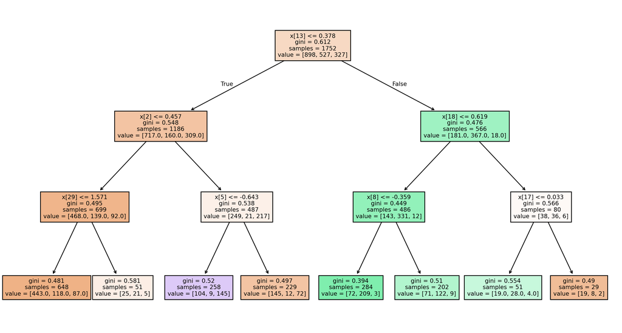

```python
import matplotlib.pyplot as plt
best_tree = dt_grid.best_estimator_.named_steps["tree"]
plt.figure(figsize=(15,8))
plot_tree(best_tree, filled=True, max_depth=3, fontsize=8)
plt.show()
```

Q2: Report the analyses from Part One for LDA, QDA, and KNN

```python
lda_full_pipe = Pipeline([
    ("ct", ct),
    ("lda", LDA())
])

param_grid = [
    {"lda__solver": ["lsqr", "eigen"], "lda__shrinkage": ["auto", 0.1, 0.3, 0.5, 0.7, 0.9]},
]

lda_full_grid = GridSearchCV(
    lda_full_pipe,
    param_grid=param_grid,
    scoring="f1_macro",
    cv=cv,
    n_jobs = -1
)

lda_full_grid.fit(X_train, y_train)

print("LDA Best Params:", lda_full_grid.best_params_)
print("LDA CV macro-F1: {:.3f}".format(lda_full_grid.best_score_))
print(classification_report(y_test, lda_full_grid.predict(X_test), digits=3))
print(confusion_matrix(y_test, lda_full_grid.predict(X_test)))
```

[output not shown]

```
LDA Best Params: {'lda__shrinkage': 0.5, 'lda__solver': 'lsqr'}
LDA CV macro-F1: 0.616
              precision    recall  f1-score   support

      hybrid      0.629     0.564     0.595       225
      indica      0.580     0.689     0.630       132
      sativa      0.438     0.427     0.432        82

    accuracy                          0.576       439
   macro avg      0.549     0.560     0.552       439
weighted avg      0.578     0.576     0.575       439

[[127  57  41]
 [ 37  91   4]
 [ 38   9  35]]
```

[output not shown]

LDA Best Params: {’lda__shrinkage’: 0.5, ’lda__solver’: ‘lsqr’} LDA CV macro-F1: 0.616 precision recall f1-score support

```
  hybrid      0.629     0.564     0.595       225
  indica      0.580     0.689     0.630       132
  sativa      0.438     0.427     0.432        82

accuracy                          0.576       439
```

macro avg 0.549 0.560 0.552 439 weighted avg 0.578 0.576 0.575 439

[[127 57 41] [ 37 91 4] [ 38 9 35]]

QDA

```python
qda_full_pipe = Pipeline([
    ("ct", ct),
    ("qda", QDA())
])

param_grid = {"qda__reg_param": [0.0,0.2, 0.5, 0.8, 0.9, 0.99]}

qda_full_grid = GridSearchCV(
    qda_full_pipe,
    param_grid=param_grid,
    scoring="f1_macro",
    cv=cv,
    n_jobs=-1
)

qda_full_grid.fit(X_train, y_train)

print("QDA Best Params:", qda_full_grid.best_params_)
print("QDA CV macro-F1:{:.3f}".format(qda_full_grid.best_score_))
print(classification_report(y_test, qda_full_grid.predict(X_test), digits=3))
print(confusion_matrix(y_test, qda_full_grid.predict(X_test)))
```

[output not shown]

[output cut: 178 more lines]

[output not shown]

```
QDA Best Params: {'qda__reg_param': 0.0}
QDA CV macro-F1:nan
              precision    recall  f1-score   support

      hybrid      0.545     0.293     0.382       225
      indica      0.412     0.530     0.464       132
      sativa      0.270     0.488     0.348        82

    accuracy                          0.401       439
   macro avg      0.409     0.437     0.398       439
weighted avg      0.454     0.401     0.400       439

[[66 83 76]
 [30 70 32]
 [25 17 40]]
```

QDA Best Params: {’qda__reg_param’: 0.0} QDA CV macro-F1: nan precision recall f1-score support

```
  hybrid      0.545     0.293     0.382       225
  indica      0.412     0.530     0.464       132
  sativa      0.270     0.488     0.348        82

accuracy                          0.401       439
```

macro avg 0.409 0.437 0.398 439 weighted avg 0.454 0.401 0.400 439

[[66 83 76] [30 70 32] [25 17 40]]

KNN

```python
from sklearn.neighbors import KNeighborsClassifier

knn_full_pipe = Pipeline([
    ("ct", ct),
    ("knn", KNeighborsClassifier())
])

param_grid = {
    "knn__n_neighbors": [3, 5, 7, 9, 11],
    "knn__weights": ["uniform", "distance"]
}

knn_full_grid = GridSearchCV(
    knn_full_pipe,
    param_grid=param_grid,
    scoring="f1_macro",
    cv=cv,
    n_jobs=-1
)

knn_full_grid.fit(X_train, y_train)

print("KNN Best Params:", knn_full_grid.best_params_)
print("KNN CV macro-F1:{:.3f}".format(knn_full_grid.best_score_))
print(classification_report(y_test, knn_full_grid.predict(X_test), digits=3))
print(confusion_matrix(y_test, knn_full_grid.predict(X_test)))
```

```
KNN Best Params: {'knn__n_neighbors': 7, 'knn__weights': 'distance'}
KNN CV macro-F1:0.511
              precision    recall  f1-score   support

      hybrid      0.571     0.698     0.628       225
      indica      0.563     0.508     0.534       132
      sativa      0.444     0.244     0.315        82

    accuracy                          0.556       439
   macro avg      0.526     0.483     0.492       439
weighted avg      0.545     0.556     0.541       439

[[157  44  24]
 [ 64  67   1]
 [ 54   8  20]]
```

KNN Best Params: {’knn__n_neighbors’: 7, ’knn__weights’: ‘distance’} KNN CV macro-F1: 0.511 precision recall f1-score support

```
  hybrid      0.571     0.698     0.628       225
  indica      0.563     0.508     0.534       132
  sativa      0.444     0.244     0.315        82

accuracy                          0.556       439
```

macro avg 0.526 0.483 0.492 439 weighted avg 0.545 0.556 0.541 439

[[157 44 24] [ 64 67 1] [ 54 8 20]]

Q3: Were your metrics better or worse than in Part One? Why? Which categories were most likely to get mixed up, according to the confusion matrices? Why?

Part Three: Multiclass from Binary Consider two models designed for binary classification: SVC and Logistic Regression

Q1: Fit and report metrics for OvR versions of the models. That is, for each of the two model types, create three models: - Indica vs. Not Indica - Sativa vs. Not Sativa - Hybrid vs. Not Hybrid

Indica vs. Not-Indica

```python
y_train_indica = (y_train == "indica").astype(int)
y_test_indica = (y_test == "indica").astype(int)

cv = StratifiedKFold(n_splits=5, shuffle=True, random_state=42)

# logistic regression (OvR)
lr_indica = Pipeline([
    ("ct", ct),
    ("lr", LogisticRegression())
])

print("LR (Indica vs. Not) - CV F1:", cross_val_score(lr_indica, X_train, y_train_indica, scoring="f1", cv=cv).mean()
)

lr_indica.fit(X_train, y_train_indica)
pred_lr = lr_indica.predict(X_test)
print("\nLR Test Report (Indica vs. Not):\n", classification_report(y_test_indica, pred_lr, digits=3))
print("LR Confusion Matrix:\n", confusion_matrix(y_test_indica, pred_lr))

# SVC (poly) OvR
svc_indica = Pipeline([
    ("ct", ct),
    ("svc", SVC(kernel="poly"))
])

print("\nSVC (poly) (Indica vs. Not) - CV F1:", cross_val_score(svc_indica, X_train, y_train_indica, scoring="f1", cv=cv).mean())

svc_indica.fit(X_train, y_train_indica)
pred_svc = svc_indica.predict(X_test)

print("\nSVC Test Report (Indica vs. Not):\n", classification_report(y_test_indica, pred_svc, digits=3))
print("SVC Confusion Matrix:\n", confusion_matrix(y_test_indica, pred_svc))
```

[output not shown]

```
LR (Indica vs. Not) - CV F1: 0.6398129647895296

LR Test Report (Indica vs. Not):
               precision    recall  f1-score   support

           0      0.825     0.847     0.836       307
           1      0.621     0.583     0.602       132

    accuracy                          0.768       439
   macro avg      0.723     0.715     0.719       439
weighted avg      0.764     0.768     0.766       439

LR Confusion Matrix:
 [[260  47]
 [ 55  77]]

SVC (poly) (Indica vs. Not) - CV F1: 0.2175791648609064

SVC Test Report (Indica vs. Not):
               precision    recall  f1-score   support

           0      0.708     0.925     0.802       307
           1      0.395     0.114     0.176       132

    accuracy                          0.681       439
   macro avg      0.551     0.519     0.489       439
weighted avg      0.614     0.681     0.614       439

SVC Confusion Matrix:
 [[284  23]
 [117  15]]
```

LR (Indica vs. Not) - CV F1: 0.6398129647895296

LR Test Report (Indica vs. Not): precision recall f1-score support

```
       0      0.825     0.847     0.836       307
       1      0.621     0.583     0.602       132

accuracy                          0.768       439
```

macro avg 0.723 0.715 0.719 439 weighted avg 0.764 0.768 0.766 439

LR Confusion Matrix: [[260 47] [ 55 77]]

SVC (poly) (Indica vs. Not) - CV F1: 0.2175791648609064

SVC Test Report (Indica vs. Not): precision recall f1-score support

```
       0      0.708     0.925     0.802       307
       1      0.395     0.114     0.176       132

accuracy                          0.681       439
```

macro avg 0.551 0.519 0.489 439 weighted avg 0.614 0.681 0.614 439

SVC Confusion Matrix: [[284 23] [117 15]]

Sativa vs. Not-Sativa

```python
y_train_sativa = (y_train == "sativa").astype(int)
y_test_sativa = (y_test == "sativa").astype(int)

# logistic regression (OvR)
lr_sativa = Pipeline([
    ("ct", ct),
    ("lr", LogisticRegression())
])

print("LR (Sativa vs. Not) - CV F1:", cross_val_score(lr_sativa, X_train, y_train_sativa, scoring="f1", cv=cv).mean())

lr_sativa.fit(X_train, y_train_sativa)
pred_lr = lr_sativa.predict(X_test)
print("\nLR Test Report (Sativa vs. Not):\n", classification_report(y_test_sativa, pred_lr, digits=3))
print("LR Confusion Matrix:\n", confusion_matrix(y_test_sativa, pred_lr))

# SVC (poly) OvR
svc_sativa = Pipeline([
    ("ct", ct),
    ("svc", SVC(kernel="poly"))
])

print("\nSVC (poly) (Sativa vs. Not) - CV F1:", cross_val_score(svc_sativa, X_train, y_train_sativa, scoring="f1", cv=cv).mean())

svc_sativa.fit(X_train, y_train_sativa)
pred_svc = svc_sativa.predict(X_test)

print("\nSVC Test Report (Sativa vs. Not):\n", classification_report(y_test_sativa, pred_svc, digits=3))
print("SVC Confusion Matrix:\n", confusion_matrix(y_test_sativa, pred_svc))
```

```
LR (Sativa vs. Not) - CV F1: 0.4188886588788212

LR Test Report (Sativa vs. Not):
               precision    recall  f1-score   support

           0      0.851     0.947     0.897       357
           1      0.548     0.280     0.371        82

    accuracy                          0.822       439
   macro avg      0.700     0.614     0.634       439
weighted avg      0.795     0.822     0.798       439

LR Confusion Matrix:
 [[338  19]
 [ 59  23]]

SVC (poly) (Sativa vs. Not) - CV F1: 0.12864670281014162

SVC Test Report (Sativa vs. Not):
               precision    recall  f1-score   support

           0      0.817     0.989     0.895       357
           1      0.429     0.037     0.067        82

    accuracy                          0.811       439
   macro avg      0.623     0.513     0.481       439
weighted avg      0.745     0.811     0.740       439

SVC Confusion Matrix:
 [[353   4]
 [ 79   3]]
```

LR (Sativa vs. Not) - CV F1: 0.4188886588788212

LR Test Report (Sativa vs. Not): precision recall f1-score support

```
       0      0.851     0.947     0.897       357
       1      0.548     0.280     0.371        82

accuracy                          0.822       439
```

macro avg 0.700 0.614 0.634 439 weighted avg 0.795 0.822 0.798 439

LR Confusion Matrix: [[338 19] [ 59 23]]

SVC (poly) (Sativa vs. Not) - CV F1: 0.12864670281014162

SVC Test Report (Sativa vs. Not): precision recall f1-score support

```
       0      0.817     0.989     0.895       357
       1      0.429     0.037     0.067        82

accuracy                          0.811       439
```

macro avg 0.623 0.513 0.481 439 weighted avg 0.745 0.811 0.740 439

SVC Confusion Matrix: [[353 4] [ 79 3]]

Hybrid vs. Not Hybrid

```python
y_train_hybrid = (y_train == "hybrid").astype(int)
y_test_hybrid = (y_test == "hybrid").astype(int)

# logistic regression (OvR)
lr_hybrid = Pipeline([
    ("ct", ct),
    ("lr", LogisticRegression())
])

print("LR (Hybrid vs. Not) - CV F1:", cross_val_score(lr_hybrid, X_train, y_train_hybrid, scoring="f1", cv=cv).mean())

lr_hybrid.fit(X_train, y_train_hybrid)
pred_lr = lr_hybrid.predict(X_test)
print("\nLR Test Report (Hybrid vs. Not):\n", classification_report(y_test_hybrid, pred_lr, digits=3))
print("LR Confusion Matrix:\n", confusion_matrix(y_test_hybrid, pred_lr))

# SVC (poly) OvR
svc_hybrid = Pipeline([
    ("ct", ct),
    ("svc", SVC(kernel="poly"))
])
print("\nSVC (poly) (Hybrid vs. Not) - CV F1:", cross_val_score(svc_hybrid, X_train, y_train_hybrid, scoring="f1", cv=cv).mean())

svc_hybrid.fit(X_train, y_train_hybrid)
pred_svc = svc_hybrid.predict(X_test)
print("\nSVC Test Report (Hybrid vs. Not):\n", classification_report(y_test_hybrid, pred_svc, digits=3))
print("SVC Confusion Matrix:\n", confusion_matrix(y_test_hybrid, pred_svc))
```

```
LR (Hybrid vs. Not) - CV F1: 0.6470795687046913

LR Test Report (Hybrid vs. Not):
               precision    recall  f1-score   support

           0      0.619     0.584     0.601       214
           1      0.624     0.658     0.641       225

    accuracy                          0.622       439
   macro avg      0.622     0.621     0.621       439
weighted avg      0.622     0.622     0.621       439

LR Confusion Matrix:
 [[125  89]
 [ 77 148]]

SVC (poly) (Hybrid vs. Not) - CV F1: 0.6581620123175869

SVC Test Report (Hybrid vs. Not):
               precision    recall  f1-score   support

           0      0.552     0.248     0.342       214
           1      0.531     0.809     0.641       225

    accuracy                          0.535       439
   macro avg      0.541     0.528     0.491       439
weighted avg      0.541     0.535     0.495       439

SVC Confusion Matrix:
 [[ 53 161]
 [ 43 182]]
```

LR (Hybrid vs. Not) - CV F1: 0.6470795687046913

LR Test Report (Hybrid vs. Not): precision recall f1-score support

```
       0      0.619     0.584     0.601       214
       1      0.624     0.658     0.641       225

accuracy                          0.622       439
```

macro avg 0.622 0.621 0.621 439 weighted avg 0.622 0.622 0.621 439

LR Confusion Matrix: [[125 89] [ 77 148]]

SVC (poly) (Hybrid vs. Not) - CV F1: 0.6581620123175869

SVC Test Report (Hybrid vs. Not): precision recall f1-score support

```
       0      0.552     0.248     0.342       214
       1      0.531     0.809     0.641       225

accuracy                          0.535       439
```

macro avg 0.541 0.528 0.491 439 weighted avg 0.541 0.535 0.495 439

SVC Confusion Matrix: [[ 53 161] [ 43 182]]

Q2: Which of the six models did the best job distinguishing the target category from the rest? Which did the worst? Does this make intuitive sense?

Sativa vs. Not Sativa: Best model = Logistic Regression CV F1 Score = 0.42

Hybrid vs. Not Hybrid: Best Model = SVC (poly) CV F1 Score = 0.66 SVC slightly beat LR (0.65); Hybrid class has more overlap

Worst performing: Sativa vs. Not Sativa (SVC and LogReg both have low F1) Sative and Hybrid share overlapping features (“Energetic”, “Happy”), making it hard for either model to find a clean boundary. Hybrid models had moderate results: both algorithms captured some structure but confused Hybrids with Indicas due to mixed traits.

Indica strains are more distinct, so even simple linear models (LogReg) can separate them, so it does make sense. Sativa and Hybrid strains overlap heavily, so both linear (LogReg) and polynomial (SVC) models struggled. SVC’s polynomial kernel helps a bit for Hybrid beause nonlinear interactions capture mixed “Indica + Sativa” characteristics.

Q3: Fit and report metrics for OvO versions of the models. That is, for each of the two model types, create three models:

- Indica vs. Sativa
- Indica vs. Hybrid
- Hybrid vs. Sativa

Indica vs. Sativa

```python
# filter for sativa and indica
X_pair = X[y.isin(["indica", "sativa"])]
y_pair = y[y.isin(["indica", "sativa"])]

cv = StratifiedKFold(n_splits=5, shuffle=True, random_state=42)

# logistic regression
lr_pipe = Pipeline([
    ("ct", ct),
    ("lr", LogisticRegression())
])

auc_lr = cross_val_score(lr_pipe, X_pair, y_pair, scoring="roc_auc", cv=cv).mean()
print("LogReg (Indica vs. Sativa) ROC-AUC:", auc_lr)

# SVC (poly)
svc_pipe = Pipeline([
    ("ct", ct),
    ("svc", SVC(kernel="poly"))
])
auc_svc = cross_val_score(svc_pipe, X_pair, y_pair, scoring="roc_auc", cv=cv).mean()
print("SVC (poly) (Indica vs. Sativa) ROC-AUC:", auc_svc)
```

```
LogReg (Indica vs. Sativa) ROC-AUC: 0.9263228699832684
SVC (poly) (Indica vs. Sativa) ROC-AUC: 0.8760026950514963
```

LogReg (Indica vs. Sativa) ROC-AUC: 0.9263228699832684 SVC (poly) (Indica vs. Sativa) ROC-AUC: 0.8760026950514963

Indica vs. Hybrid

```python
X_pair = X[y.isin(["indica", "hybrid"])]
y_pair = y[y.isin(["indica", "hybrid"])]

auc_lr = cross_val_score(lr_pipe, X_pair, y_pair, scoring="roc_auc_ovr", cv=cv).mean()
auc_svc = cross_val_score(svc_pipe, X_pair, y_pair, scoring="roc_auc_ovr", cv=cv).mean()

print("LogReg (Indica vs Hybrid) ROC-AUC:", auc_lr)
print("SVC (poly) (Indica vs. Hybrid) ROC-AUC:", auc_svc)
```

[output not shown]

[output cut: 11 more lines]

[output not shown]

```
LogReg (Indica vs Hybrid) ROC-AUC: 0.7910503689659224
SVC (poly) (Indica vs. Hybrid) ROC-AUC: nan
```

Hybrid vs. Sativa

```python
X_pair = X[y.isin(["hybrid", "sativa"])]
y_pair = y[y.isin(["hybrid", "sativa"])]

auc_lr = cross_val_score(lr_pipe, X_pair, y_pair, scoring="roc_auc", cv=cv).mean()
auc_svc = cross_val_score(svc_pipe, X_pair, y_pair, scoring="roc_auc", cv=cv).mean()

print("LogReg (Hybrid vs Sativa) ROC-AUC:", auc_lr)
print("SVC (poly) (Hybrid vs. Sativa) ROC-AUC:", auc_svc)
```

```
LogReg (Hybrid vs Sativa) ROC-AUC: 0.7359636512238138
SVC (poly) (Hybrid vs. Sativa) ROC-AUC: 0.6732759609364172
```

LogReg (Hybrid vs Sativa) ROC-AUC: 0.7359636512238138 SVC (poly) (Hybrid vs. Sativa) ROC-AUC: 0.6732759609364172

Q4: Which of the six models did the best job distinguishing at differentiating the two groups? Which did the worst? Does this make intuitive sense?

Best Overall Model: Logisitic Regression for Indica vs. Sativa The Logistic Regression ROC-AUC score for the Indica vs. Sativa model was the highest with a score of 0.926 of all the six model. This makes sense because Indica and Sativa are the most distinguishable cannabis strains. They have different effects, flavors, and feelings which cluster more better so a linear classifier can separate them well.

Worst Model: The worst overall model was the SVC for Hybrid vs. Sativa, with a ROC-AUC score of 0.673 which was the lowest of the six. This was consistent with the other model results from part 2. Hybrid and Sativa were the hardest pair due to overlap in their effect/feeling, both sharing similar descriptors and because of this similarity, the SVC polynomial boundary wasn’t enough to distinguish them.

Q5: Suppose you had simply input the full data, with three classes, into the LogisticRegression function. Would this have automatically taken an “OvO” approach or an “OvR” approach? What about SVC?